# Analysis: Incidence of cancer in Scotland

Cancer in Scotland

Lesley Duff

2023-11-13

# Incidence

## Background

There are *multiple* different types of cancer. We would like to find out which types have been recorded in Scotland and how these have changed over time.

Different cancers are categorised (coded) according to World Health Organisation (WHO) [International Statistical Classification of Diseases and Related Health Problems (ICD)](https://www.who.int/standards/classifications/classification-of-diseases). In Scotland, currently the ‘ICD-10’ code is used when a patient is diagnosed to record which type of cancer they have. Example of an ICD-10 code: C50 = ‘Breast’ cancer.

### Terminology

Technical terms used relating to this dataset.

| Term | Description |
| --- | --- |
| **incidence** | The total number of new cases (registrations) of the cancer diagnosed in Scotland for the given period. |
| **cancer site** | The place where a cancer starts in the body. This is represented as a code and also a human readable name. |

The [Scottish Cancer Registry and Intelligence Service](https://publichealthscotland.scot/our-areas-of-work/conditions-and-diseases/cancer/scottish-cancer-registry-and-intelligence-service-scris/overview/) (SCRIS) collects detailed information on every cancer in Scotland. However, this raw information is **not public** and can only be directly accessed by people in the NHS and approved individuals.

Public Health Scotland (PHS) makes available extracts from the SCRIS as open data. For this analysis the [Annual Cancer Incidence](https://www.opendata.nhs.scot/dataset/annual-cancer-incidence) data will be used. Specifically [Incidence at Scotland Level](https://www.opendata.nhs.scot/dataset/annual-cancer-incidence/resource/72c852b8-ee28-4fd8-84a9-5f415f4bc325). Annual number and rate of new cancer registrations in Scotland by sex and age.

Cancer incidence in Scotland To December 2021)

The following dataset gives us an annual number and rate of new cancer registrations in Scotland by sex and age. Reports include data from 1997 to 2021.

**Source:** [Incidence at Scotland Level](https://www.opendata.nhs.scot/dataset/c2c59eb1-3aff-48d2-9e9c-60ca8605431d/resource/72c852b8-ee28-4fd8-84a9-5f415f4bc325/download/opendata_inc9721_scotland.csv). PHS Last update: 29 March 2023.

This analysis utilises PHS data. Their sex data uses ‘Females’ plural but “Male” singular, this has been left to match the original.

### Important! When is a medical cancer a ‘cancer’ in official reports?

“‘All cancers’ by convention **excludes non-melanoma skin cancers**.” - PHS.

Non-melanoma skin cancers are in the original open data supplied. To keep consistent with the official reporting standard ‘Non-melanoma skin cancers’ have been excluded from this analysis. -  
[Cancer incidence in Scotland To December 2021](https://publichealthscotland.scot/publications/cancer-incidence-in-scotland/cancer-incidence-in-scotland-to-december-2021/)

## Analysis

This dataset covers years 1997-2021.

### Time: Cancer Incidences by Year and Sex

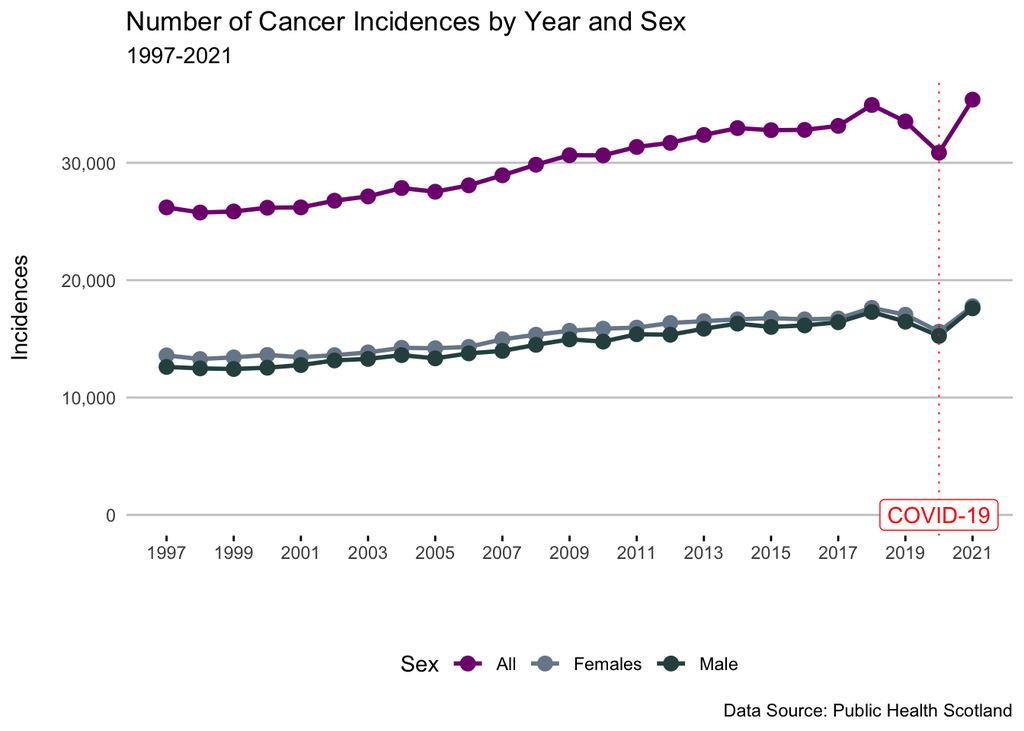

The higher the incidences, the more people have been formally diagnosed as having a new case of cancer. Shows incidences in general, started increasing in number in 1998 to 2018. Then dropped from 2019 to 2020 (start of COVID). In most recent year of results available 2021 numbers rose sharply to the highest level ever.

### Summary: Incidences by Sex

Summary statistics Incidences by Sex

Data between: 1997 and 2021

| Result | Total | Mean | Median |
| --- | --- | --- | --- |
| All | 749,411 | 29,976 | 30,634 |
| Females | 383,143 | 15,326 | 15,615 |
| Male | 366,268 | 14,651 | 14,766 |

Data Source: Public Health Scotland

On average in Scotland there are almost 30,000 new incidences of cancer each year. Females have a higher average(mean) and median number of incidences per year than males but bear in mind there is a slightly higher number of females in the population of Scotland. These figures are relatively close in spite of sexes having some completely different types of cancer risk due to different organs.

> The 2021 estimates for Scotland’s population produced by National Records of Scotland (NRS) show that Scotland’s overall population stands at 5.48 million: 2.67 million males and 2.8 million females.  
> [Population: estimates, Scotland, Scottish Public Health Observatory](https://www.scotpho.org.uk/population-dynamics/population-estimates-and-projections/data/population-estimates/#:~:text=Scotland,males%20and%202.8%20million%20females.)

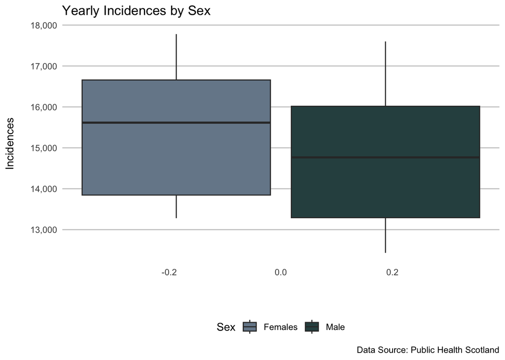

Displays the summary statistics for yearly incidences for both sexes. Even taking COVID-19 in to account there are no outliers - no years stand out as being significantly different from the others. The median for females is higher and males and the distribution is more negatively skewed.

Years with highest/lowest cancer incidences

Data between: 1997 and 2021

| Result | Incidences | Year |
| --- | --- | --- |
| Highest | 35,379 | 2021 |
| Lowest | 12,432 | 1999 |

Data Source: Public Health Scotland

Cancer incidences had been steadily increasing since the late 1990s before starting to drop in 2019, note this was the year *before* COVID-19 started. Unfortunately the most recent year of data the cases are at their highest number ever. This has to be caveated with our growing and ageing population. So the drop on the year of COVID-19 itself might have been part of an already decreasing trend. There was widespread disruption to health services and daily life. All manner of primary care (e.g. GP practices) and diagnostic services were interrupted completely or on heavily reduced capacity which may give some administrative reasons for a drop in formal diagnoses. The steep rise 2020-2021 may have a backlog of previously undiagnosed cases as part of that increase.

GPs commented at the time that a lot of patients weren’t coming to them. they are often the first point of contact for those with symptoms/concerns eventually leading to a formal cancer diagnosis. [“GPs are worried about “missing patients” and the backlog which has built up in chronic disease management, screening, immunisation and cancer referrals.” DEEP END REPORT 36 General Practice in the time of Covid-19](https://www.gla.ac.uk/media/Media_728030_smxx.pdf) June 2020.

People with weak immune systems were more vulnerable to negative outcomes from the virus and the elderly being more likely to die from COVID-19 may also have had the side effect of reducing the number of old people with a diagnosis of a new case of cancer. This is probably the sort of question that might be able to be tested by those with access to the Scottish Cancer Registry to track patients with other multiple conditions.

### Types of Cancer (Cancer Sites)

#### Abbreviations for charts

Some of the names of the cancers are rather long. To help make these more legible on charts the following substitutions have been made. If you see “…” next to a name it means it’s been adjusted to use the names in the following table.

Abbreviations for Cancer Site names

| Short Name | Cancer Site |
| --- | --- |
| ALL... | Acute lymphoblastic leukaemia |
| AML | Acute myeloid leukaemia |
| Bone & A... | Bone and articular cartilage |
| Bone & C... | Bone and connective tissue |
| Brain | Malignant brain cancer |
| Brain & CNS... | All brain and CNS tumours (malignant and non-malignant) |
| Brain incl... | Malig brain ca (incl pit. gland, cranio. duct, pineal gland) |
| CLL... | Chronic lymphocytic leukaemia |
| CML... | Chronic myeloid leukaemia |
| Colorectal... | Colorectal cancer |
| Connective... | Connective tissue |
| Head... | Head and neck |
| Hodgkin... | Hodgkin lymphoma |
| Lip/Oral... | Lip, oral cavity and pharynx |
| Liver & bile... | Liver and intrahepatic bile ducts |
| Lung... | Trachea, bronchus and lung |
| Mouth... | Mouth (IARC definition) |
| Myeloma... | Multiple myeloma and malignant plasma cell neoplasms |
| Non-Hodgkin... | Non-Hodgkin lymphoma |
| Oropharyngeal... | Oropharyngeal cancers |
| Rectum... | Rectum and rectosigmoid junction |
| Salivary... | Salivary glands |
| Skin... | Malignant melanoma of the skin |

#### Incidences by Year and Cancer Sites

In Scotland cancers are categorised (coded) to World Health Organisation standards.

Here are the **recorded*** cancers for the all the years available (1997-2021) in the dataset.

There are **45** types of cancer (cancer sites). Some of these names are themselves umbrella categories of other more specific sub-categories e.g. ‘Leukaemias’ and ‘Colorectal cancer’ (Colon+Rectum) might be better known by the public as ‘Bowel’ cancer.

These represent multiple years and all ages and sexes.  
* Some excluded from all cancer reporting e.g. non-malignant skin cancer.

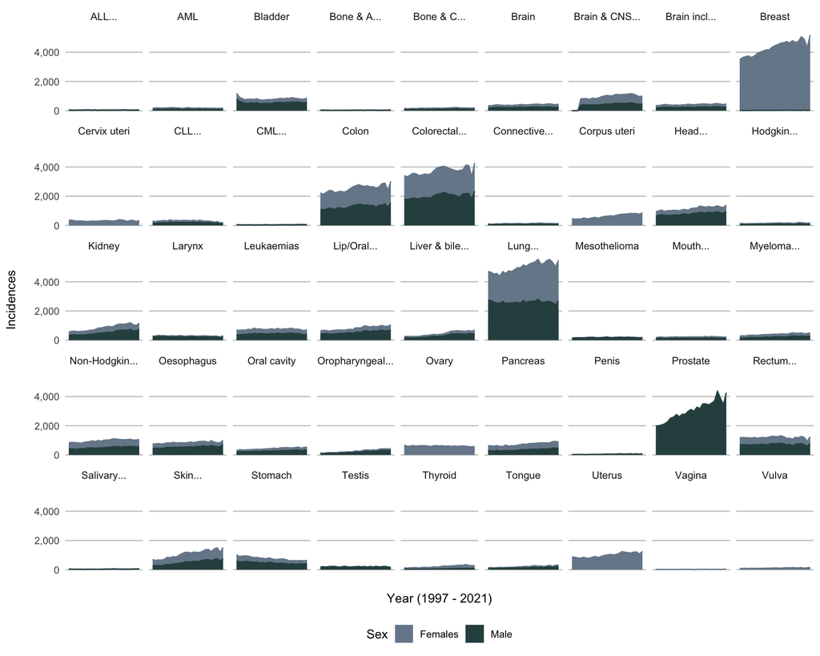

##### All time (1997-2021)

Cancer Sites in Scotland

Between: 1997 and 2021

| Cancer Site | Total |
| --- | --- |
| Trachea, bronchus and lung | 125,189 |
| Breast | 107,964 |
| Colorectal cancer | 93,160 |
| Prostate | 75,673 |
| Colon | 63,337 |
| Rectum and rectosigmoid junction | 29,823 |
| Head and neck | 28,792 |
| Malignant melanoma of the skin | 26,912 |
| Uterus | 24,988 |
| Non-Hodgkin lymphoma | 24,345 |
| All brain and CNS tumours (malignant and non-malignant) | 21,788 |
| Kidney | 21,561 |
| Oesophagus | 21,314 |
| Bladder | 20,622 |
| Lip, oral cavity and pharynx | 20,444 |
| Stomach | 19,119 |
| Leukaemias | 18,651 |
| Pancreas | 18,290 |
| Corpus uteri | 15,779 |
| Ovary | 15,273 |
| Liver and intrahepatic bile ducts | 11,227 |
| Oral cavity | 10,898 |
| Malig brain ca (incl pit. gland, cranio. duct, pineal gland) | 10,581 |
| Malignant brain cancer | 10,149 |
| Multiple myeloma and malignant plasma cell neoplasms | 10,095 |
| Cervix uteri | 7,993 |
| Chronic lymphocytic leukaemia | 7,706 |
| Larynx | 7,333 |
| Oropharyngeal cancers | 6,714 |
| Mouth (IARC definition) | 5,598 |
| Thyroid | 5,390 |
| Tongue | 5,300 |
| Testis | 5,117 |
| Mesothelioma | 4,876 |
| Acute myeloid leukaemia | 4,577 |
| Bone and connective tissue | 4,466 |
| Hodgkin lymphoma | 3,852 |
| Connective tissue | 3,286 |
| Vulva | 2,842 |
| Acute lymphoblastic leukaemia | 1,548 |
| Chronic myeloid leukaemia | 1,498 |
| Penis | 1,399 |
| Salivary glands | 1,285 |
| Bone and articular cartilage | 1,180 |
| Vagina | 601 |

Data Source: Public Health Scotland

Lung, Breast, Bowel and Prostate alone account for over 53% of the total.

##### Most recent year available (2021)

For comparison here is the list only for the latest year of data.

Cancer Sites in Scotland

2021

| Cancer Site | Total |
| --- | --- |
| Trachea, bronchus and lung | 5,476 |
| Breast | 5,180 |
| Colorectal cancer | 4,279 |
| Prostate | 4,265 |
| Colon | 3,023 |
| Malignant melanoma of the skin | 1,525 |
| Head and neck | 1,400 |
| Rectum and rectosigmoid junction | 1,256 |
| Uterus | 1,254 |
| Kidney | 1,162 |
| Non-Hodgkin lymphoma | 1,067 |
| Lip, oral cavity and pharynx | 1,045 |
| All brain and CNS tumours (malignant and non-malignant) | 1,006 |
| Oesophagus | 997 |
| Pancreas | 887 |
| Bladder | 863 |
| Corpus uteri | 860 |
| Leukaemias | 713 |
| Liver and intrahepatic bile ducts | 686 |
| Stomach | 641 |
| Ovary | 576 |
| Oral cavity | 538 |
| Multiple myeloma and malignant plasma cell neoplasms | 503 |
| Malig brain ca (incl pit. gland, cranio. duct, pineal gland) | 468 |
| Malignant brain cancer | 451 |
| Oropharyngeal cancers | 422 |
| Cervix uteri | 342 |
| Tongue | 319 |
| Larynx | 313 |
| Thyroid | 281 |
| Mouth (IARC definition) | 219 |
| Bone and connective tissue | 209 |
| Chronic lymphocytic leukaemia | 197 |
| Mesothelioma | 195 |
| Acute myeloid leukaemia | 172 |
| Hodgkin lymphoma | 170 |
| Testis | 166 |
| Vulva | 163 |
| Connective tissue | 142 |
| Penis | 86 |
| Salivary glands | 80 |
| Chronic myeloid leukaemia | 72 |
| Bone and articular cartilage | 67 |
| Acute lymphoblastic leukaemia | 66 |
| Vagina | 36 |

Data Source: Public Health Scotland

What might be worth watching is which cancer sites are in a higher position in the 2021 table as this may show cancers that are starting to become more prevalent. e.g. “Malignant melanoma of the skin” and “Head and neck” have moved to positions ahead of “Rectum and rectosigmoid junction” and “Kidney” now makes the top 10 whereas “Non-Hodgkin lymphoma” drops to 11th.

### Age Range

What age are people when they are newly diagnosed. Would knowing the demographics of different diseases affect what kind of public health information and awareness raising needs to be done? The next tables are based on all of the years of data available.

#### Top Incidences by Cancer Site, Age Range and Sex

This is a list of those cancer sites, age groups and sexes most at risk of having a new cancer diagnosed.

Top 10 All

| Cancer Site | Age Range | Sex | Incidences |
| --- | --- | --- | --- |
| Prostate | 70-74 | Male | 15,828 |
| Prostate | 65-69 | Male | 14,738 |
| Breast | 50-54 | Females | 13,552 |
| Breast | 60-64 | Females | 13,517 |
| Prostate | 75-79 | Male | 13,275 |
| Breast | 65-69 | Females | 13,122 |
| Trachea, bronchus and lung | 70-74 | Male | 12,911 |
| Breast | 55-59 | Females | 12,368 |
| Trachea, bronchus and lung | 75-79 | Male | 11,904 |
| Trachea, bronchus and lung | 70-74 | Females | 11,126 |

Data Source: Public Health Scotland

Next an example of how different the top risks by cancer site can be by age and sex.

Top 5 Females 20-29

| Cancer Site | Age Range | Sex | Incidences |
| --- | --- | --- | --- |
| Uterus | 25-29 | Females | 647 |
| Cervix uteri | 25-29 | Females | 635 |
| Malignant melanoma of the skin | 25-29 | Females | 514 |
| Breast | 25-29 | Females | 354 |
| Malignant melanoma of the skin | 20-24 | Females | 322 |

Data Source: Public Health Scotland

Next, an example of what age range and sex might be more at risk of a specific cancer type.

Top 5 Hodgkin lymphoma

| Cancer Site | Age Range | Sex | Incidences |
| --- | --- | --- | --- |
| Hodgkin lymphoma | 20-24 | Females | 192 |
| Hodgkin lymphoma | 25-29 | Male | 192 |
| Hodgkin lymphoma | 20-24 | Male | 187 |
| Hodgkin lymphoma | 40-44 | Male | 184 |
| Hodgkin lymphoma | 30-34 | Male | 183 |

Data Source: Public Health Scotland

#### Incidences by Age Range, Sex and Cancer Site

Here we have age-related data where incidences have been provided in 5-year categories from 0, .. to 90+. This data gives us the chance to consider the relationship between ageing and risk of being diagnosed with a new cancer.

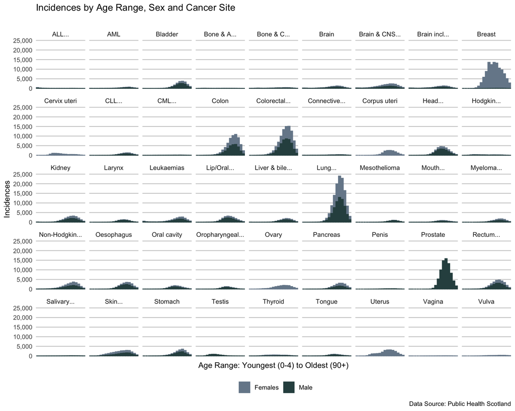

We see 4 main cancers dominating in terms of numbers Colorectal/Lung/Breast and Prostate. The pattern over many cancers in terms of age range is that most of them really become much more prevalent from middle age onwards, peaking for new cases for most sites when we are in our 70s.

Of these big 4 “Breast” seems highest at younger ages than the other 3 so awareness raising should start in younger age groups. The ones that buck that trend higher more in the first half of life tend to be the ones associated with “Cervix uteri” (Cervical) in females and “Testis” (Testicular) in males.

**Suggestion:**

- Is the public aware of the increased risk simply by ageing? Are there opportunities to raise awareness among people engaging with other health or public sector organisations to be watchful for early symptoms that might be higher risks according to the age of the person.
- There are already screening programmes for breast/bowel and cervical cancer. Lung and Prostate cancer are some of the top in terms of numbers. Is there some equivalent of screening for these two in particular? If not, keep informed of any developments in early detection of these two.

## Project Output: Cancer Risk Tool

In the course of this analysis an interactive Cancer Risk Tool has been produced that allows users to experiment with changing age/sex and cancer site and getting an idea of what the risk of that combination might be. This is leveraging the value of a multi-decade dataset in capturing risk in Scotland.

**Technical Note:**

The tool will be found in the “cancer_risk_tool” folder that accompanies this report. It is an experimental demo and requires the user to run the *Shiny R Markdown* document by opening the file and clicking “Run Document”.

Below is a screenshot of the tool in action.

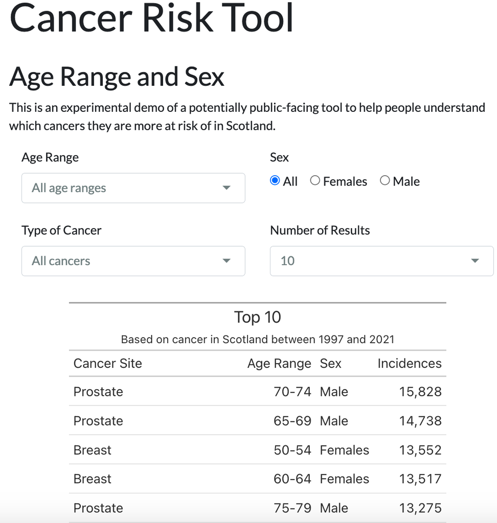

Cancer Risk Tool Screenshot